# Pemodelan ARIMA - Pendugaan Parameter, Diagnostik Model, dan Peramalan

## 8 Analisis Sisaan

Model terbaik hasil identifikasi kemudian dicek asumsi sisaannya. Sisaan model ARIMA harus memenuhi asumsi normalitas, kebebasan, dan kehomogenan ragam. Diagnostik model dilakukan secara eksplorasi dan uji formal.

### 8.1 Eksplorasi Sisaan

```r
#Eksplorasi
sisaan <- m201$residuals
par(mfrow=c(2,2))
car::qqPlot(sisaan, main = "Normal Q-Q Plot", ylab = "Sisaan")
```

```
[1] 118  83
```

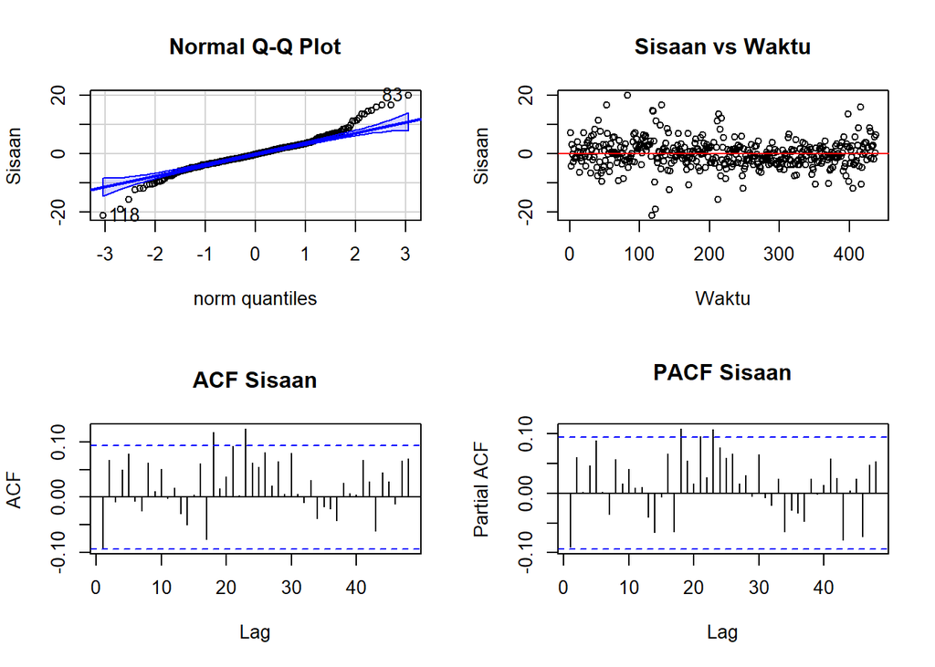

```r
plot(sisaan, type = "p", main = "Sisaan vs Waktu", xlab = "Waktu", ylab = "Sisaan")
abline(h = 0, col = "red")
acf(sisaan,  main = "ACF Sisaan",  lag.max = 48)
pacf(sisaan, main = "PACF Sisaan", lag.max = 48)
```

Pada plot Q-Q, sebagian besar titik mengikuti garis, tetapi ujung-ujungnya menyimpang sehingga normalitas diragukan. Plot sisaan terhadap waktu menunjukkan lebar pita yang kurang seragam (ada periode sisaan lebih besar), yang mengindikasikan ragam tidak homogen. Pada ACF/PACF sisaan, lag-lag awal tidak signifikan, tetapi muncul spike kecil di sekitar lag 18 dan lag 23 yang menandakan masih ada sisa autokorelasi pada lag yang lebih jauh (kemungkinan terkait pola harian). Kondisi ini diuji lebih lanjut secara formal.

## 9 Uji Formal

### 9.1 Kenormalan Sisaan

$H_0$ : Sisaan menyebar normal $H_1$ : Sisaan tidak menyebar normal

```r
ks_res <- ks.test(sisaan, "pnorm", mean(sisaan), sd(sisaan))
ks_res
```

```
    Asymptotic one-sample Kolmogorov-Smirnov test

data:  sisaan
D = 0.075603, p-value = 0.01338
alternative hypothesis: two-sided
```

```r
shapiro.test(sisaan)
```

```
    Shapiro-Wilk normality test

data:  sisaan
W = 0.95526, p-value = 2.926e-10
```

Pada uji Kolmogorov-Smirnov, sisaan harus dibandingkan dengan sebaran normal dengan rataan dan simpangan baku sisaan sendiri (menggunakan pnorm standar tanpa parameter akan keliru karena sisaan tidak berskala standar). Didapat p-value lebih kecil dari 5% sehingga tolak $H_0$: sisaan tidak menyebar normal. Ini sesuai dengan penyimpangan di ujung plot Q-Q. (Peringatan ties pada KS muncul karena data kelembapan berupa bilangan bulat.)

### 9.2 Kebebasan Sisaan

$H_0$ : Sisaan saling bebas $H_1$ : Sisaan tidak tidak saling bebas

```r
lb1  <- Box.test(sisaan, type = "Ljung")
lb24 <- Box.test(sisaan, lag = 24, type = "Ljung", fitdf = 3)
lb1; lb24
```

```
    Box-Ljung test

data:  sisaan
X-squared = 3.6228, df = 1, p-value = 0.05699
```

```
    Box-Ljung test

data:  sisaan
X-squared = 38.351, df = 21, p-value = 0.01172
```

Pada lag 1, p-value sebesar 0.057, sedikit di atas 5% sehingga gagal tolak $H_0$. Namun ketika diuji sampai lag 24 (satu siklus harian, dengan derajat bebas disesuaikan fitdf = 3), p-value sebesar 0.0117 lebih kecil dari 5% sehingga tolak $H_0$: masih ada autokorelasi pada sisaan, yang kemungkinan besar bersumber dari pola harian (periode 24) yang belum ditangkap model.

### 9.3 Kehomogenan Ragam Sisaan

$H_0$ : Ragam sisaan homogen $H_1$ : Ragam sisaan tidak homogen

```r
lb_sq <- Box.test(sisaan^2, type = "Ljung")
lb_sq
```

```
    Box-Ljung test

data:  sisaan^2
X-squared = 33.488, df = 1, p-value = 7.169e-09
```

*P-value* lebih kecil dari 5% sehingga tolak $H_0$: ragam sisaan tidak homogen (ada indikasi efek ARCH). Ini sesuai dengan plot sisaan terhadap waktu.

### 9.4 Nilai Tengah Sisaan

$H_0$ : nilai tengah sisaan sama dengan 0 $H_1$ : nilai tengah sisaan tidak sama dengan 0

```r
tt <- t.test(sisaan, mu = 0, conf.level = 0.95)
tt
```

```
    One Sample t-test

data:  sisaan
t = -0.10614, df = 437, p-value = 0.9155
alternative hypothesis: true mean is not equal to 0
95 percent confidence interval:
 -0.4695495  0.4214340
sample estimates:
  mean of x
-0.02405777
```

*P-value* lebih besar dari 5% sehingga gagal tolak $H_0$: nilai tengah sisaan sama dengan nol.

### 9.5 Ringkasan Uji Formal

```r
data.frame(
  Asumsi = c("Normalitas (KS)", "Normalitas (Shapiro)", "Kebebasan (Ljung-Box lag 1)",
             "Kebebasan (Ljung-Box lag 24)", "Homogenitas ragam", "Nilai tengah nol"),
  P_value = signif(c(ks_res$p.value, shapiro.test(sisaan)$p.value, lb1$p.value,
                     lb24$p.value, lb_sq$p.value, tt$p.value), 3),
  Keputusan = c("Tidak terpenuhi", "Tidak terpenuhi", "Terpenuhi (batas)",
                "Tidak terpenuhi", "Tidak terpenuhi", "Terpenuhi")
)
```

```
                        Asumsi  P_value         Keputusan
1              Normalitas (KS) 1.34e-02   Tidak terpenuhi
2         Normalitas (Shapiro) 2.93e-10   Tidak terpenuhi
3  Kebebasan (Ljung-Box lag 1) 5.70e-02 Terpenuhi (batas)
4 Kebebasan (Ljung-Box lag 24) 1.17e-02   Tidak terpenuhi
5            Homogenitas ragam 7.17e-09   Tidak terpenuhi
6             Nilai tengah nol 9.16e-01         Terpenuhi
```

Hanya asumsi nilai tengah nol yang terpenuhi dengan jelas. Pelanggaran normalitas dan homogenitas ragam umum terjadi pada data kelembapan karena nilainya dibatasi 0-100%, dan pelanggaran kebebasan sampai lag 24 mengindikasikan perlunya mencoba model musiman. Model ARIMA(2,0,1) tetap digunakan karena tujuan praktikum ini adalah penerapan alur ARIMA nonmusiman, dan keterbatasan tersebut dicatat pada kesimpulan.

## 10 Overfitting

Overfitting dilakukan dengan menaikkan orde p atau q dari model terpilih ARIMA(2,0,1), yaitu ARIMA(3,0,1) dan ARIMA(2,0,2), untuk melihat apakah ada model yang lebih baik.

```r
m301 <- Arima(df.train, order = c(3,0,1), method = "ML")
summary(m301); coeftest(m301)
```

```
Series: df.train
ARIMA(3,0,1) with non-zero mean

Coefficients:
```

```
         ar1     ar2      ar3     ma1     mean
      1.0122  0.1993  -0.3071  0.1316  69.1120
s.e.     NaN     NaN      NaN     NaN   2.6595

sigma^2 = 23.8:  log likelihood = -1314.48
AIC=2640.96   AICc=2641.16   BIC=2665.46

Training set error measures:
                    ME     RMSE      MAE        MPE     MAPE      MASE
Training set -0.067284 4.850715 3.502035 -0.6641103 5.313314 0.9191528
                    ACF1
Training set -0.05700155
```

```
z test of coefficients:

          Estimate Std. Error z value  Pr(>|z|)
ar1        1.01216        NaN     NaN       NaN
ar2        0.19926        NaN     NaN       NaN
ar3       -0.30710        NaN     NaN       NaN
ma1        0.13163        NaN     NaN       NaN
intercept 69.11196    2.65947  25.987 < 2.2e-16 ***
---
Signif. codes:  0 '***' 0.001 '**' 0.01 '*' 0.05 '.' 0.1 ' ' 1
```

```r
overfitting <- data.frame(
  Model = c("ARIMA(2,0,1)", "ARIMA(3,0,1)", "ARIMA(2,0,2)"),
  AIC = c(AIC(m201), AIC(m301), AIC(m202)),
  BIC = c(BIC(m201), BIC(m301), BIC(m202))
)
overfitting
```

```
         Model      AIC      BIC
1 ARIMA(2,0,1) 2618.633 2639.044
2 ARIMA(3,0,1) 2640.963 2665.457
3 ARIMA(2,0,2) 2681.112 2705.605
```

Kedua model hasil overfitting memiliki AIC dan BIC lebih besar dibandingkan ARIMA(2,0,1), dan parameternya tidak seluruhnya dapat diuji (galat baku NaN). Karena itu model ARIMA(2,0,1) tetap dipilih untuk peramalan.

## 11 Peramalan

Peramalan dilakukan dengan fungsi `forecast()` sepanjang data uji (110 jam ke depan).

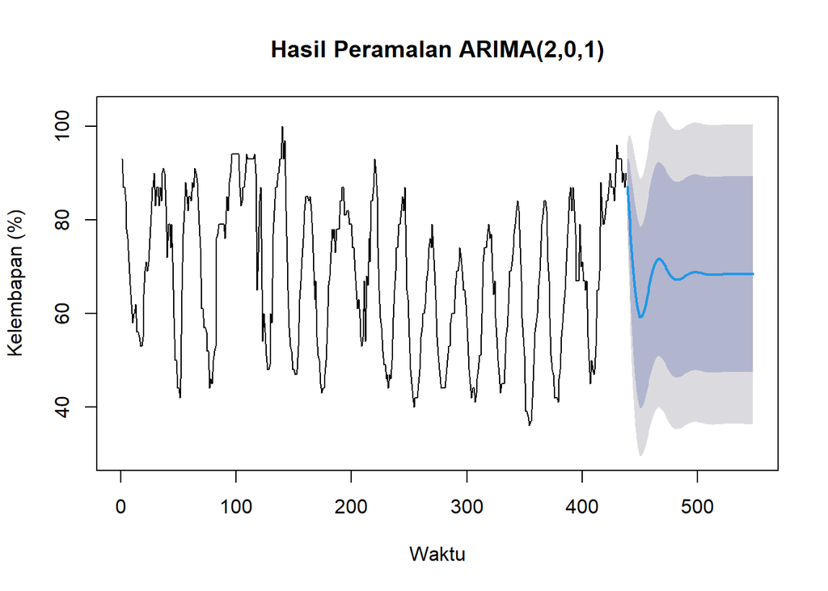

```r
ramalan <- forecast::forecast(m201, h = length(test))
data.ramalan <- ramalan$mean
plot(ramalan, main = "Hasil Peramalan ARIMA(2,0,1)", xlab = "Waktu", ylab = "Kelembapan (%)")
```

Ramalan bergerak mendekati nilai tengah (rata-rata) data dan hanya mengikuti pola jangka pendek. Selang kepercayaan melebar lalu stabil. Hal ini wajar karena model ARMA nonmusiman cepat kembali ke rataan dan tidak menangkap pola harian.

```r
perbandingan <- data.frame(Waktu = (ntrain + 1):n, Aktual = df.test,
                           Forecast = round(as.numeric(data.ramalan), 2))
head(perbandingan, 10)
```

```
   Waktu Aktual Forecast
1    439     74    87.09
2    440     71    83.76
3    441     55    80.21
4    442     51    76.60
5    443     43    73.10
6    444     45    69.84
7    445     43    66.91
8    446     41    64.41
9    447     42    62.37
10   448     50    60.84
```

```r
akurasi <- accuracy(as.numeric(data.ramalan), test)
akurasi
```

```
                ME     RMSE      MAE       MPE     MAPE
Test set -2.057288 17.18444 14.97804 -10.60175 26.35155
```

Pada data uji, diperoleh RMSE sebesar 17.18, MAE 14.98, dan MAPE 26.35%. Nilai kesalahan yang cukup besar ini terjadi karena ramalan jangka panjang cenderung datar, sementara data aktual masih berayun mengikuti pola harian.

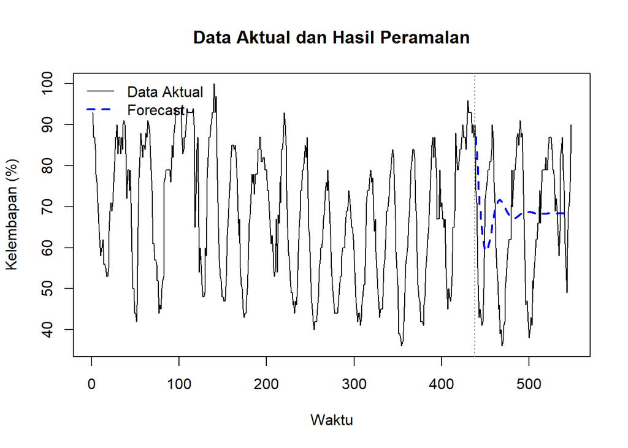

```r
ts.plot(df.ts, col = "black", lty = 1, xlab = "Waktu", ylab = "Kelembapan (%)",
        main = "Data Aktual dan Hasil Peramalan")
lines((ntrain + 1):n, as.numeric(data.ramalan), col = "blue", lty = 2, lwd = 2)
abline(v = ntrain, col = "gray50", lty = 3)
legend("topleft", legend = c("Data Aktual", "Forecast"),
       col = c("black", "blue"), lty = c(1, 2), lwd = c(1, 2), bty = "n")
```

## 12 Kesimpulan

- Data kelembapan per jam stasioner dalam rataan (uji ADF) dan ragam (Box-Cox memuat $\lambda = 1$, sehingga tidak perlu differencing.
- Dari ACF, PACF, dan EACF diperoleh enam model tentatif; ARIMA(2,0,1) terpilih karena AIC/BIC terkecil dan seluruh parameternya signifikan. Overfitting tidak menghasilkan model yang lebih baik.
- Sisaan memiliki nilai tengah nol, tetapi tidak normal, tidak homogen, dan secara kumulatif masih berautokorelasi sampai lag 24.
- Peramalan 110 jam ke depan cenderung datar di sekitar rataan dengan RMSE 17.18.